# Introduction to Python Project : FoodHub Data Analysis

### Problem Statement

Foodhub is online food aggregator company. To improve its business they have hired a data scientist to extract information from the data which they have accumulated.

They want to get an idea on the demand of different restaurants which will hep them to improve customer experience.

### Data Dictionary

order_id - Unique Id of the order

customer_id - ID of the customer who ordered the food

restaurant_name - Name of the restaurant

cuisine_type - Cusine ordered by the customer

cost_of_the_order - Cost of the order

day_of_the_week - Indicates whether the order is placed on weekday or weekend (Weekday is Monday to Friday and Weekend is Saturday and Sunday)

rating - Rating given by the customer out of 5.

food_preparation_time - Time in minutes taken by restaurant to prepare the food

delivery_time - Time(in minutes) taken by delivery person to deliver the food package

### Let us start by importing the required libraries

```python
# import necessary libraries for the project
import numpy as np
import pandas as pd
import seaborn as sns
import matplotlib.pyplot as plt
```

### Understanding the structure of the data

```python
# run the following lines for Google Colab
from google.colab import drive
drive.mount('/content/drive')
```

```python
# read the data
df = pd.read_csv('/content/drive/MyDrive/Projects/Python_FoodHub/foodhub_order.csv')
```

```python
# Write your code here to view the first 5 rows
df.head()
```

|  | order_id | customer_id | restaurant_name | cuisine_type | cost_of_the_order | day_of_the_week | rating | food_preparation_time | delivery_time |
| --- | --- | --- | --- | --- | --- | --- | --- | --- | --- |
| 0 | 1477147 | 337525 | Hangawi | Korean | 30.75 | Weekend | Not given | 25 | 20 |
| 1 | 1477685 | 358141 | Blue Ribbon Sushi Izakaya | Japanese | 12.08 | Weekend | Not given | 25 | 23 |
| 2 | 1477070 | 66393 | Cafe Habana | Mexican | 12.23 | Weekday | 5 | 23 | 28 |
| 3 | 1477334 | 106968 | Blue Ribbon Fried Chicken | American | 29.20 | Weekend | 3 | 25 | 15 |
| 4 | 1478249 | 76942 | Dirty Bird to Go | American | 11.59 | Weekday | 4 | 25 | 24 |

### **Question 1:** How many rows and columns are present in the data? [0.5 mark]

```python
# Write your code here
df.shape
```

```
(1898, 9)
```

#### Observations:

The shape attribute gives the number of rows and columns for a dataFrame.

For the data for foodhub below are the observations:

No of Rows - 1898

No of Columns - 9

### **Question 2:** What are the datatypes of the different columns in the dataset? (The info() function can be used) [0.5 mark]

```python
# Write your code here
df.info()
```

```
<class 'pandas.core.frame.DataFrame'>
RangeIndex: 1898 entries, 0 to 1897
Data columns (total 9 columns):
 #   Column                 Non-Null Count  Dtype
---  ------                 --------------  -----
 0   order_id               1898 non-null   int64
 1   customer_id            1898 non-null   int64
 2   restaurant_name        1898 non-null   object
 3   cuisine_type           1898 non-null   object
 4   cost_of_the_order      1898 non-null   float64
 5   day_of_the_week        1898 non-null   object
 6   rating                 1898 non-null   object
 7   food_preparation_time  1898 non-null   int64
 8   delivery_time          1898 non-null   int64
dtypes: float64(1), int64(4), object(4)
memory usage: 133.6+ KB
```

#### Observations:

The Dataset contains a total of 9 columns out of which

There is 1 Column with datatype as Float.

There are 4 Column with datatype as Int/Number.

There are 4 Column with datatype as Object/String.

The Rating column contains a Not Given rating due to which the column type is an object.

### **Question 3:** Are there any missing values in the data? If yes, treat them using an appropriate method. [1 mark]

```python
# Write your code here
print(df.isnull().sum())
print('-'*50)
print(df['order_id'].isna().value_counts(dropna=False))
print('-'*50)
print(df['customer_id'].isna().value_counts(dropna=False))
print('-'*50)
print(df['restaurant_name'].isna().value_counts(dropna=False))
print('-'*50)
print(df['cuisine_type'].isna().value_counts(dropna=False))
print('-'*50)
print(df['cost_of_the_order'].isna().value_counts(dropna=False))
print('-'*50)
print(df['day_of_the_week'].isna().value_counts(dropna=False))
print('-'*50)
print(df['rating'].isna().value_counts(dropna=False))
print('-'*50)
print(df['food_preparation_time'].isna().value_counts(dropna=False))
print('-'*50)
print(df['delivery_time'].isna().value_counts(dropna=False))
```

```
order_id                 0
customer_id              0
restaurant_name          0
cuisine_type             0
cost_of_the_order        0
day_of_the_week          0
rating                   0
food_preparation_time    0
delivery_time            0
dtype: int64
--------------------------------------------------
order_id
False    1898
Name: count, dtype: int64
--------------------------------------------------
customer_id
False    1898
Name: count, dtype: int64
--------------------------------------------------
restaurant_name
False    1898
Name: count, dtype: int64
--------------------------------------------------
cuisine_type
False    1898
Name: count, dtype: int64
--------------------------------------------------
cost_of_the_order
False    1898
Name: count, dtype: int64
--------------------------------------------------
day_of_the_week
False    1898
Name: count, dtype: int64
--------------------------------------------------
rating
False    1898
Name: count, dtype: int64
--------------------------------------------------
food_preparation_time
False    1898
Name: count, dtype: int64
--------------------------------------------------
delivery_time
False    1898
Name: count, dtype: int64
```

```python
df['rating'].unique()
```

```
array(['Not given', '5', '3', '4'], dtype=object)
```

#### Observations:

1. There are no missing values in the dataset.
2. If we check the data the rating column consists of 'Not Given' rating but it is not considered as null values or missing data.

### **Question 4:** Check the statistical summary of the data. What is the minimum, average, and maximum time it takes for food to be prepared once an order is placed? [2 marks]

```python
# Write your code here
df.loc[:, ~df.columns.isin(['order_id', 'customer_id'])].describe(include='all').T
```

|  | count | unique | top | freq | mean | std | min | 25% | 50% | 75% | max |
| --- | --- | --- | --- | --- | --- | --- | --- | --- | --- | --- | --- |
| restaurant_name | 1898 | 178 | Shake Shack | 219 | NaN | NaN | NaN | NaN | NaN | NaN | NaN |
| cuisine_type | 1898 | 14 | American | 584 | NaN | NaN | NaN | NaN | NaN | NaN | NaN |
| cost_of_the_order | 1898.0 | NaN | NaN | NaN | 16.498851 | 7.483812 | 4.47 | 12.08 | 14.14 | 22.2975 | 35.41 |
| day_of_the_week | 1898 | 2 | Weekend | 1351 | NaN | NaN | NaN | NaN | NaN | NaN | NaN |
| rating | 1898 | 4 | Not given | 736 | NaN | NaN | NaN | NaN | NaN | NaN | NaN |
| food_preparation_time | 1898.0 | NaN | NaN | NaN | 27.37197 | 4.632481 | 20.0 | 23.0 | 27.0 | 31.0 | 35.0 |
| delivery_time | 1898.0 | NaN | NaN | NaN | 24.161749 | 4.972637 | 15.0 | 20.0 | 25.0 | 28.0 | 33.0 |

#### Observations:

The Maximum number of orders are from Shake Shack Restaurant.

The Cuisine which is maximum ordered is American.

Weekend is more preferred thn weekday for ordering food.

Food Preparation Time

- Min - 20 minutes
- Average - 27.37 minutes (2 floating point decimals)
- Max - 35 minutes

Delivery Time

- Min - 15 minutes
- Average - 24.16 minutes (2 floating point decimals)
- Max - 33 minutes

Cost Of the order

- Min - 4.47
- Average - 16.50
- Max - 35.41

### **Question 5:** How many orders are not rated? [1 mark]

```python
# Write the code here
df['rating'].value_counts()
```

| rating | count |
| --- | --- |
| Not given | 736 |
| 5 | 588 |
| 4 | 386 |
| 3 | 188 |

**dtype:** int64

#### Observations:

1. There are a total of 736 orders where the rating is 'Not Given' and are not rated.

### Exploratory Data Analysis (EDA)

### **Question 6:** Explore all the variables and provide observations on their distributions. (Generally, histograms, boxplots, countplots, etc. are used for univariate exploration.) [9 marks]

#### Observation on customer_id

```python
print("The number of unique customer Ids are", df['customer_id'].nunique())
```

```
The number of unique customer Ids are 1200
```

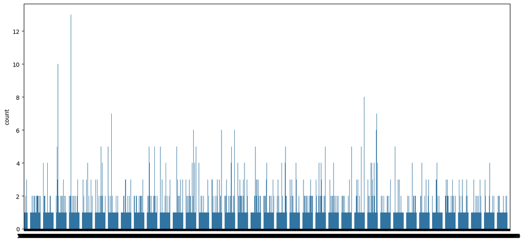

```python
plt.figure(figsize=(15,7))
customer_countplot = sns.countplot(data=df, x='customer_id')
customer_countplot.set(xlabel=None)
plt.show()
```

```python
result = df['customer_id'].value_counts()
result_df = result.reset_index()
result_df.columns = ['customer_id', 'no_of_orders']
print("No of customers wrt No Of Orders")
print(result_df.head(5))
result_data = result_df['no_of_orders'].value_counts()
result_data = result_data.reset_index()
result_data.columns = ['no_of_orders', 'no_of_customers']
result_data
```

```
No of customers wrt No Of Orders
   customer_id  no_of_orders
0        52832            13
1        47440            10
2        83287             9
3       250494             8
4       259341             7
```

|  | no_of_orders | no_of_customers |
| --- | --- | --- |
| 0 | 1 | 784 |
| 1 | 2 | 267 |
| 2 | 3 | 83 |
| 3 | 4 | 33 |
| 4 | 5 | 19 |
| 5 | 6 | 6 |
| 6 | 7 | 4 |
| 7 | 9 | 1 |
| 8 | 10 | 1 |
| 9 | 13 | 1 |
| 10 | 8 | 1 |

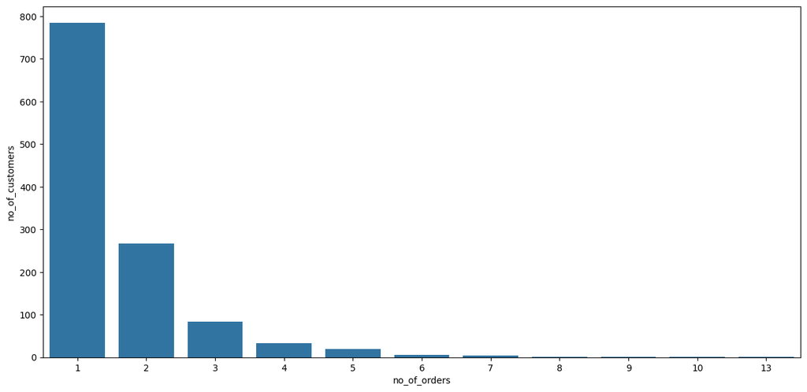

```python
plt.figure(figsize=(15,7))
sns.barplot(data=result_data, y='no_of_customers', x='no_of_orders')
plt.show()
```

**Observation**

1. With the count plot we an see that there are customers which have placed more than 1 orders.
2. The barplot shows No of Orders on the x axis and no of customers on the y axis, eg. There are approximately 780 customers who have ordered only 1 time. Similarly there is 1 customer who has ordered 13 times.

#### Observation on resturant_name

```python
top_10_restaurants = df['restaurant_name'].value_counts().head(10)
top_10_restaurants_df = top_10_restaurants.reset_index()
top_10_restaurants_df.columns = ['restaurant_name', 'total_orders']
top_10_restaurants_df
```

|  | restaurant_name | total_orders |
| --- | --- | --- |
| 0 | Shake Shack | 219 |
| 1 | The Meatball Shop | 132 |
| 2 | Blue Ribbon Sushi | 119 |
| 3 | Blue Ribbon Fried Chicken | 96 |
| 4 | Parm | 68 |
| 5 | RedFarm Broadway | 59 |
| 6 | RedFarm Hudson | 55 |
| 7 | TAO | 49 |
| 8 | Han Dynasty | 46 |
| 9 | Blue Ribbon Sushi Bar & Grill | 44 |

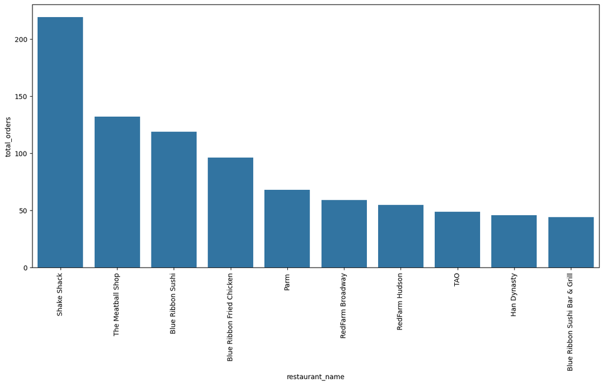

```python
plt.figure(figsize=(15,7))
sns.barplot(data=top_10_restaurants_df, x='restaurant_name', y='total_orders')
plt.xticks(rotation = 90)
plt.show()
```

**Observations**

1. With the barplot we are plotting top 10 restaurants wrt total number of orders from each restaurant.
2. Shake Shack is the restaurant with the most number of orders from it.

#### Observation on cuisine type

```python
df['cuisine_type'].unique()
```

```
array(['Korean', 'Japanese', 'Mexican', 'American', 'Indian', 'Italian',
       'Mediterranean', 'Chinese', 'Middle Eastern', 'Thai', 'Southern',
       'French', 'Spanish', 'Vietnamese'], dtype=object)
```

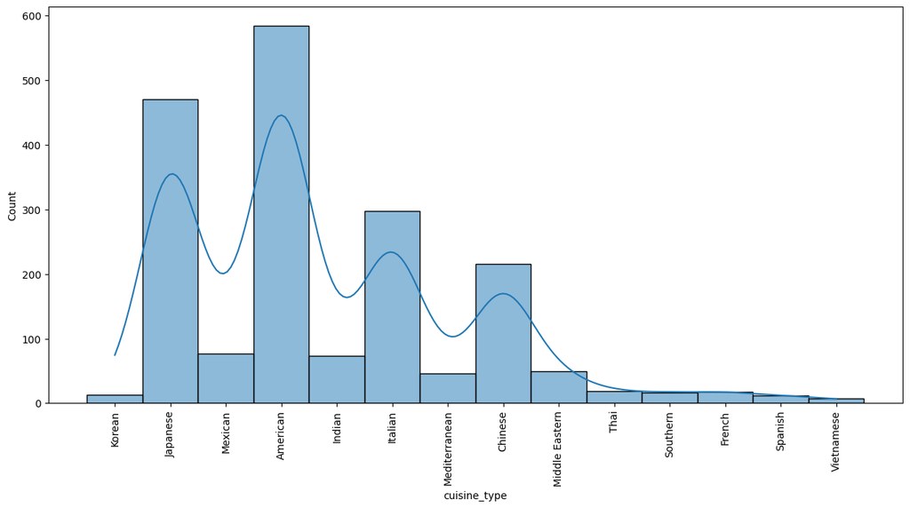

```python
plt.figure(figsize=(15,7))
sns.histplot(data=df['cuisine_type'], kde=True);
plt.xticks(rotation = 90)
plt.show()
```

**Observation**

1. With Histogram, we are plotting the cuisine type with respect to the number of times that cuisine has been ordered.
2. KDE plot of the histogran tells the probability distribution of the variable.

#### Observation on cost_of_the order

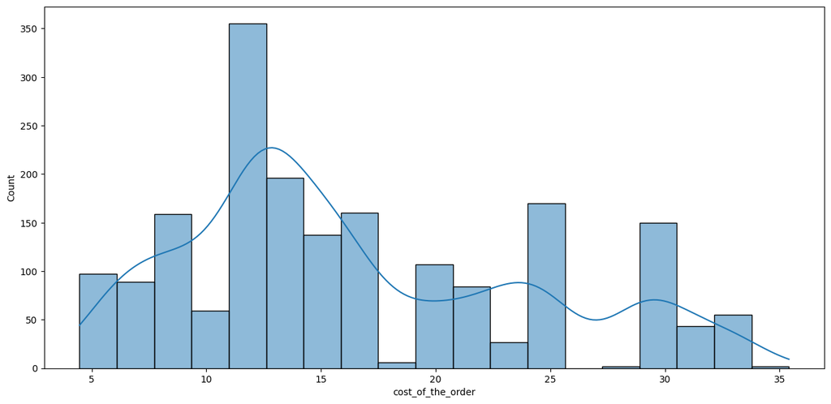

```python
plt.figure(figsize=(15,7))
sns.histplot(data=df['cost_of_the_order'], kde=True)
plt.show()
```

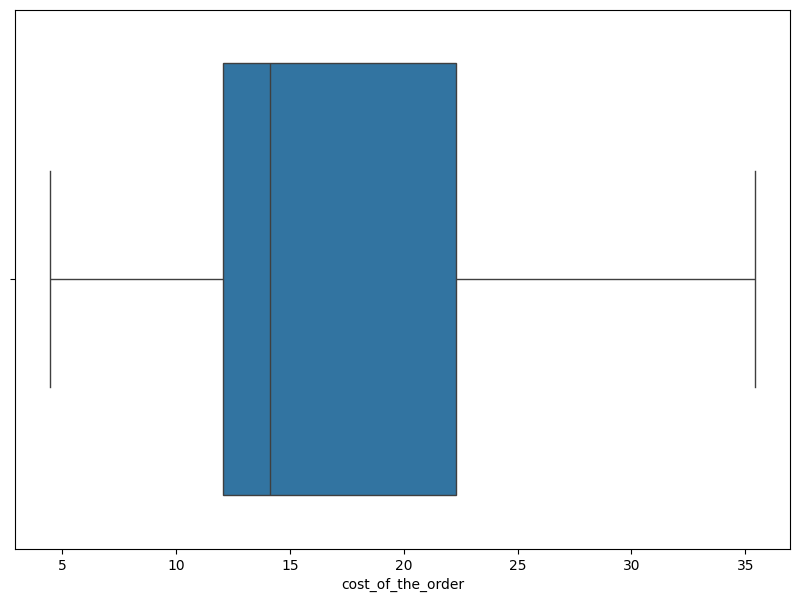

```python
plt.figure(figsize=(10,7))
sns.boxplot(data=df, x='cost_of_the_order')
plt.show()
```

**Observations**

1. Histogram plot shows the number of orders with the specific cost of the order and kde plot describes he probability density of the cost of the order.
2. Bos plot depicts the median cost of order is below 15 dollars. 75% of the orders are below 23 dollars.

#### Observation on day of the week

```python
df['day_of_the_week'].unique()
```

```
array(['Weekend', 'Weekday'], dtype=object)
```

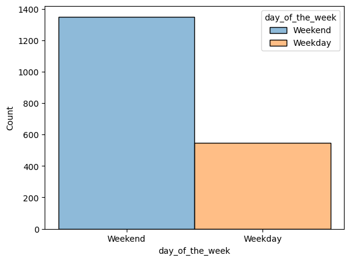

```python
sns.histplot(data=df, x='day_of_the_week', hue="day_of_the_week")
plt.show()
```

**Observations**

1. The histogram plot shows the numbers of orders on a weekday and on weekends.
2. The no of orders on weekend are much more then on a weekday.

#### Observation on rating

```python
df['rating'].unique()
```

```
array(['Not given', '5', '3', '4'], dtype=object)
```

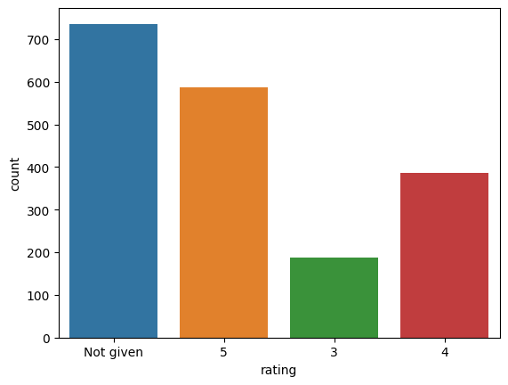

```python
sns.countplot(data=df, x='rating', hue='rating')
```

**Observations**

1. The countplot shows what rating was given to the orders. There are approximately 730 orders where the rating is not given.

#### Observation on Food Preparation time

```python
df['food_preparation_time'].unique()
```

```
array([25, 23, 20, 28, 33, 21, 29, 34, 24, 30, 35, 32, 31, 27, 22, 26])
```

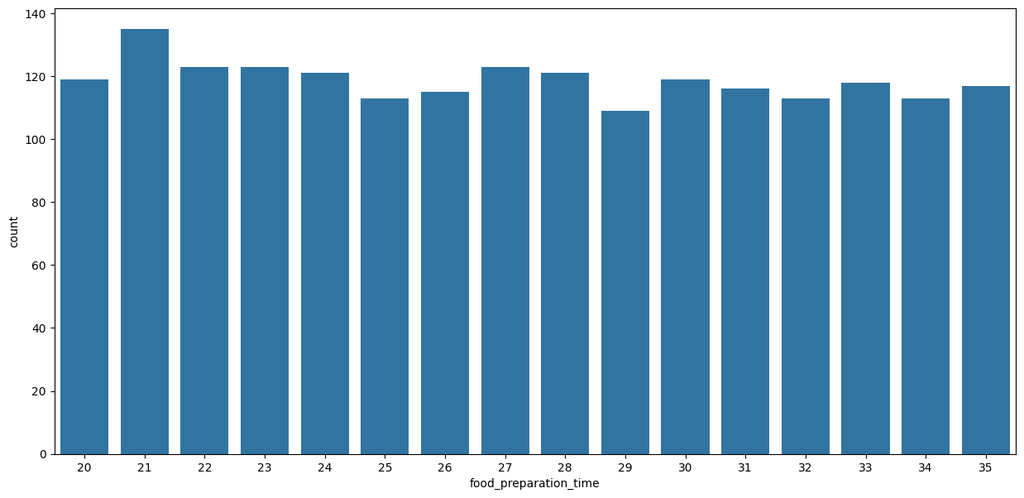

```python
plt.figure(figsize=(15,7))
sns.countplot(data=df, x='food_preparation_time')
plt.show()
```

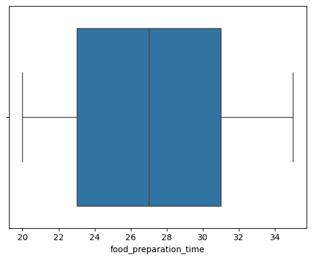

```python
sns.boxplot(data=df, x='food_preparation_time')
```

**Observations**

1. Data for food preparation time only tells that the median time for orders is around 27 minutes.

#### Observation on delivery time

```python
df['delivery_time'].unique()
```

```
array([20, 23, 28, 15, 24, 21, 30, 26, 22, 17, 25, 16, 29, 27, 18, 31, 32,
       19, 33])
```

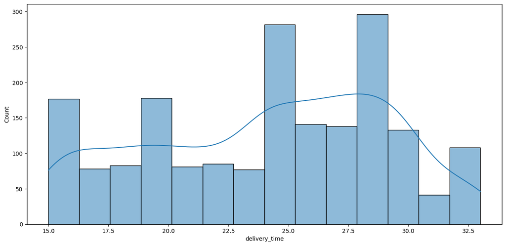

```python
plt.figure(figsize=(15,7))
sns.histplot(data=df, x='delivery_time', kde=True)
plt.show()
```

**Observations**

1. Histogram plot of delivery time column shows data is a bit left skewed which tells that orders have a high delivery time.

### **Question 7**: Which are the top 5 restaurants in terms of the number of orders received? [1 mark]

```python
# Write the code here
df['restaurant_name'].value_counts().head(5)
```

| restaurant_name | count |
| --- | --- |
| Shake Shack | 219 |
| The Meatball Shop | 132 |
| Blue Ribbon Sushi | 119 |
| Blue Ribbon Fried Chicken | 96 |
| Parm | 68 |

**dtype:** int64

**Observations**:

- Shake Shack has the maximum number of orders received at 219 orders.
- The Meatball shop, Blue Ribbon Sushi, Blue Ribbon Fried Chicken, Parm occupy the 2nd, 3rd, 4th, 5th places respcetively.

### **Question 8**: Which is the most popular cuisine on weekends? [1 mark]

```python
# Write the code here
#(df[df['day_of_the_week']=='Weekend']).groupby('day_of_the_week')['cuisine_type'].value_counts().head(1)
df[df['day_of_the_week']=='Weekend']['cuisine_type'].value_counts()
```

| cuisine_type | count |
| --- | --- |
| American | 415 |
| Japanese | 335 |
| Italian | 207 |
| Chinese | 163 |
| Mexican | 53 |
| Indian | 49 |
| Middle Eastern | 32 |
| Mediterranean | 32 |
| Thai | 15 |
| French | 13 |
| Korean | 11 |
| Southern | 11 |
| Spanish | 11 |
| Vietnamese | 4 |

**dtype:** int64

#### Observations:

- Most popular Quisine on Weekends is American with 415 orders.

### **Question 9**: What percentage of the orders cost more than 20 dollars? [2 marks]

```python
# Write the code here
df.head()
number_of_orders_above20 = df[df['cost_of_the_order']>20].shape[0]
print("Number of Orders above $20 is", number_of_orders_above20)
print('Total number of orders', df.shape[0])
print('Percentage of orders above $20 is', (number_of_orders_above20/df.shape[0])*100)
```

```
Number of Orders above $20 is 555
Total number of orders 1898
Percentage of orders above $20 is 29.24130663856691
```

#### Observations:

- Orders which cost more than 20 dollars percentage is 29.24%.

### **Question 10**: What is the mean order delivery time? [1 mark]

```python
# Write the code here
print(df['delivery_time'].mean());
```

```
24.161749209694417
```

#### Observations:

- Mean delivery time is ~24.16 minutes

### **Question 11:** The company has decided to give 20% discount vouchers to the top 3 most frequent customers. Find the IDs of these customers and the number of orders they placed. [1 mark]

```python
# Write the code here

df['customer_id'].value_counts().head(3)
```

| customer_id | count |
| --- | --- |
| 52832 | 13 |
| 47440 | 10 |
| 83287 | 9 |

**dtype:** int64

#### Observations:

- Customer with Customer Id 52832 has placed 13 Orders and is the most frequent Customer.
- Customer with Customer Id 47440 has placed 10 Orders and is the 2nd most frequent Customer.
- Customer with Customer Id 83287 has placed 9 Orders and is the 3rd most frequent Customer.

### **Question 12**: Perform a multivariate analysis to explore relationships between the important variables in the dataset. (It is a good idea to explore relations between numerical variables as well as relations between numerical and categorical variables) [10 marks]

#### Observation on Numerical Columns Corelation

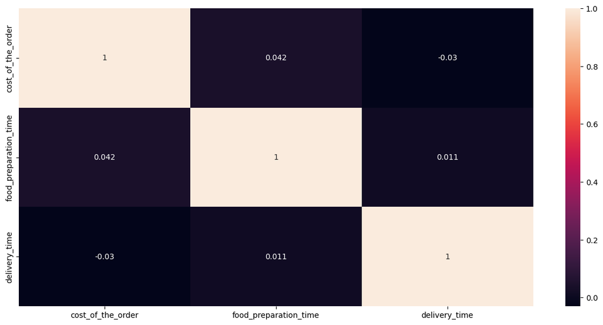

```python
# Write the code here
df_without_orderId = df.drop(['order_id'], axis=1)
df_without_customerId = df_without_orderId.drop(['customer_id'], axis=1)
plt.figure(figsize=(15,7))
sns.heatmap(data=df_without_customerId.corr(numeric_only=True), annot=True)
plt.show()
```

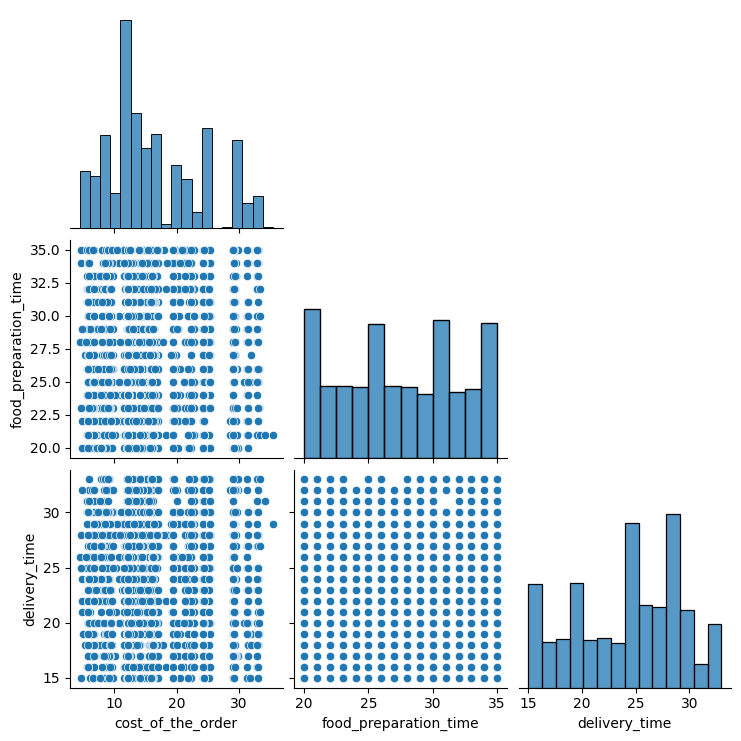

```python
plt.figure(figsize=(15,7))
sns.pairplot(data=df_without_customerId[['cost_of_the_order', 'food_preparation_time', 'delivery_time']], corner=True)
plt.show()
```

**Observations**

1. According to the heatmap plot and pairplot the numerical variables dont have a strong corelation between them.

#### Observation on Restaurant Name and Cost of order

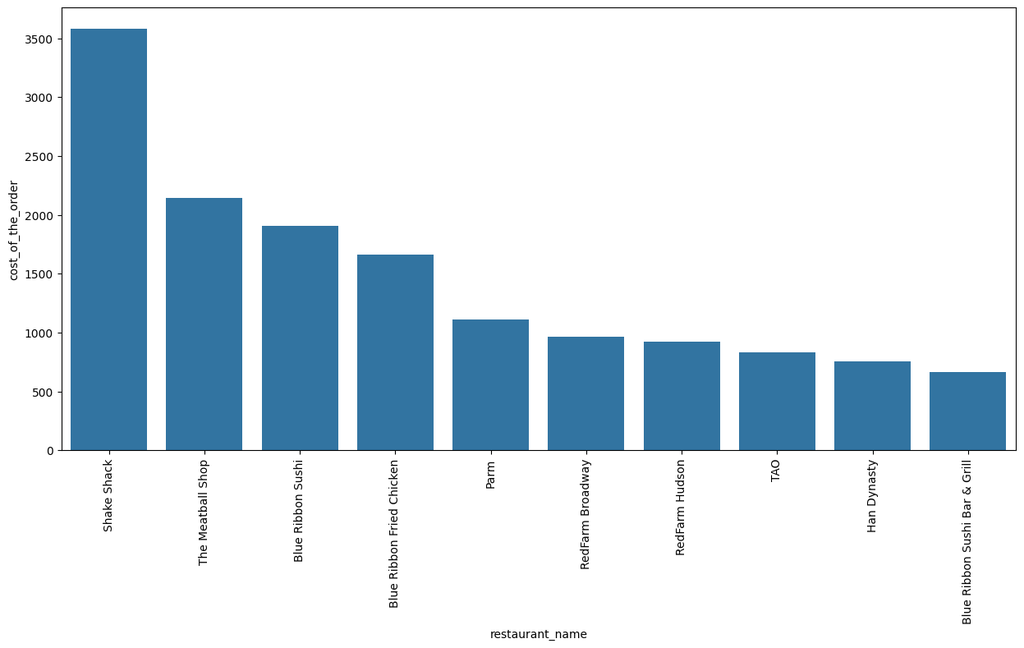

```python
plt.figure(figsize=(15,7))
sns.barplot(data=df_without_customerId.groupby('restaurant_name')['cost_of_the_order'].sum().sort_values(ascending=False).head(10))
plt.xticks(rotation=90)
plt.show()
```

**Observations**

1. The sum of cost of all the orders with respect to restaurant name is plotted in the bar plot above and the restaurant with maximum cost of all orders is shake shack.

#### Obsrvation on Cuisine Type and Cost of the order

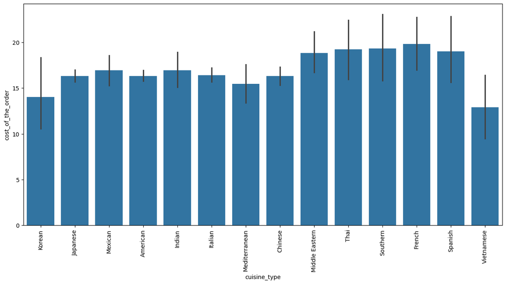

```python
plt.figure(figsize=(15,7))
sns.barplot(data=df_without_customerId, x='cuisine_type', y='cost_of_the_order')
plt.xticks(rotation=90)
plt.show()
```

**Observations**

1. Above bar plot shows the mean cost of order for every cuisine and french is the cuisine with the highest mean order value.

#### Observation on Cuisine type and Rating

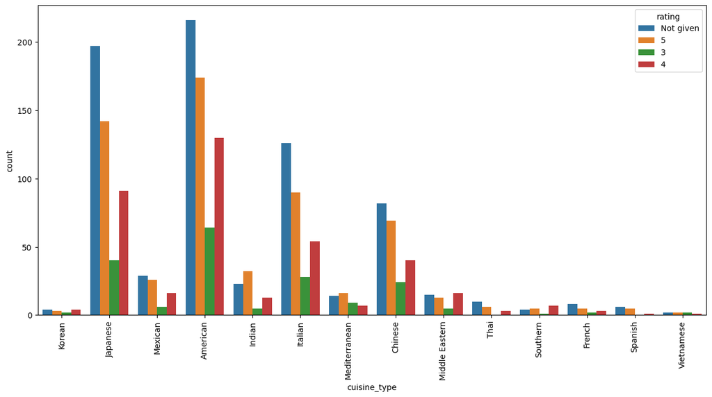

```python
plt.figure(figsize=(15,7))
sns.countplot(data=df_without_customerId, x='cuisine_type', hue='rating')
plt.xticks(rotation=90)
plt.show()
```

**Observations**

1. Countplot shows the count of the rating as hue for each cuisine.
2. American Cuisine is the one where most of the ratings are given this cuisine has the highest number of orders as well.

#### Observation on Cuisine Type and Day Of the Week

```python
df.groupby('cuisine_type')['day_of_the_week'].value_counts(normalize=True)
```

| cuisine_type | day_of_the_week | proportion |
| --- | --- | --- |
| American | Weekend | 0.710616 |
|  | Weekday | 0.289384 |
| Chinese | Weekend | 0.758140 |
|  | Weekday | 0.241860 |
| French | Weekend | 0.722222 |
|  | Weekday | 0.277778 |
| Indian | Weekend | 0.671233 |
|  | Weekday | 0.328767 |
| Italian | Weekend | 0.694631 |
|  | Weekday | 0.305369 |
| Japanese | Weekend | 0.712766 |
|  | Weekday | 0.287234 |
| Korean | Weekend | 0.846154 |
|  | Weekday | 0.153846 |
| Mediterranean | Weekend | 0.695652 |
|  | Weekday | 0.304348 |
| Mexican | Weekend | 0.688312 |
|  | Weekday | 0.311688 |
| Middle Eastern | Weekend | 0.653061 |
|  | Weekday | 0.346939 |
| Southern | Weekend | 0.647059 |
|  | Weekday | 0.352941 |
| Spanish | Weekend | 0.916667 |
|  | Weekday | 0.083333 |
| Thai | Weekend | 0.789474 |
|  | Weekday | 0.210526 |
| Vietnamese | Weekend | 0.571429 |
|  | Weekday | 0.428571 |

**dtype:** float64

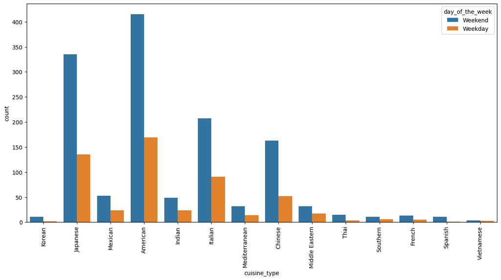

```python
plt.figure(figsize=(15,7))
sns.countplot(data=df_without_customerId, x='cuisine_type', hue='day_of_the_week')
plt.xticks(rotation=90)
plt.show()
```

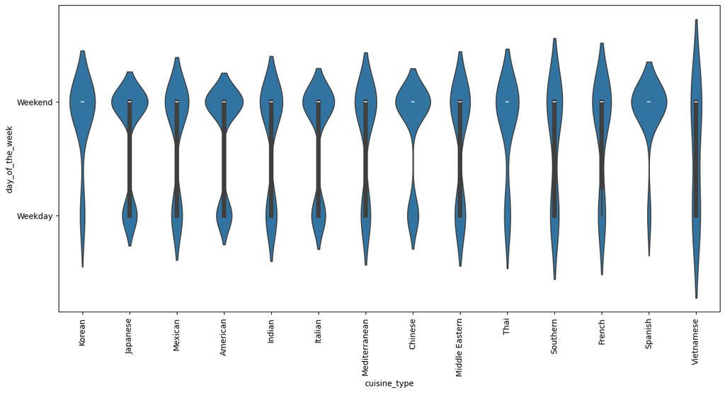

```python
plt.figure(figsize=(15,7))
sns.violinplot(data=df_without_customerId, x='cuisine_type', y='day_of_the_week')
plt.xticks(rotation=90)
plt.show()
```

**Observations**

1. The above plots show how is the cuisine data distributed over the day of the week.
2. The violin plot shows How are the percentage orders are over the weekend and weekdays.
3. Spanish Cuisine has ~91% of the orders during the weekend.

#### Observation on Cuisine Type and Food Delivery Time

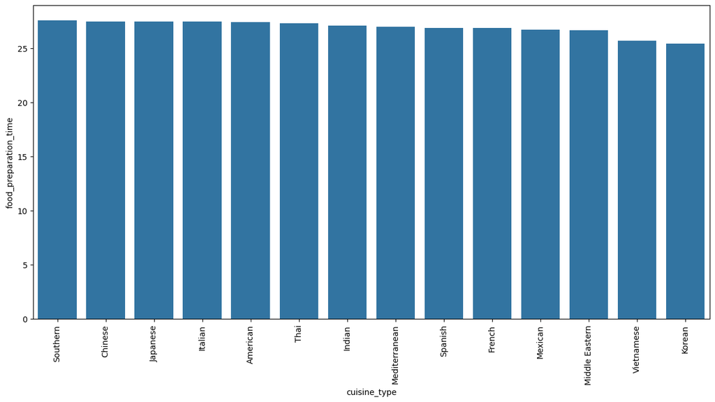

```python
plt.figure(figsize=(15,7))
sns.barplot(data=df_without_customerId.groupby('cuisine_type')['food_preparation_time'].mean().sort_values(ascending=False))
plt.xticks(rotation=90)
plt.show()
```

**Observation**

1. There are no noticeable observations between cuisine type and food preparation time.

#### Observations on day_of_the_week and Delivery Time

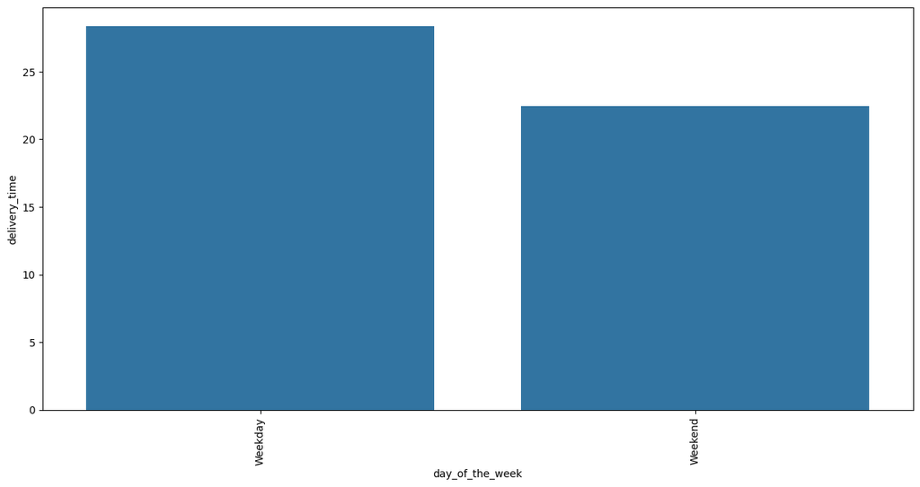

```python
plt.figure(figsize=(15,7))
sns.barplot(data=df_without_customerId.groupby('day_of_the_week')['delivery_time'].mean())
plt.xticks(rotation=90)
plt.show()
```

**Observation**

1. The Delivery Time is lesser on the weekends then on Weekends.
2. Ideally due to more number of orders on weekends the delivery time should be higher.

#### Observation on Day of the Week and Cost of the order

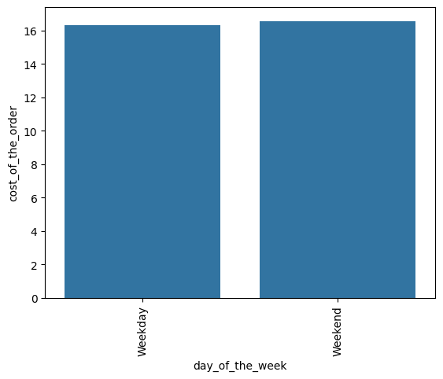

```python
sns.barplot(data=df_without_customerId.groupby('day_of_the_week')['cost_of_the_order'].mean())
plt.xticks(rotation=90)
plt.show()
```

**Observations**

1. There is no notieable difference in the mean order value on the Weekend or Weekday.

#### Observation on Rating and Cost of the order with Hue as day of the week

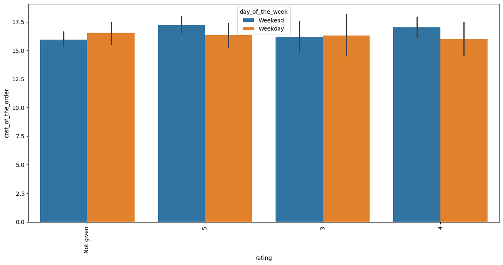

```python
plt.figure(figsize=(15,7))
sns.barplot(data=df_without_customerId, x='rating', y='cost_of_the_order', hue='day_of_the_week')
plt.xticks(rotation=90)
plt.show()
```

**Observations**

1. No Noticeable observations on the above graph.

#### Observations on rating nd delivery time

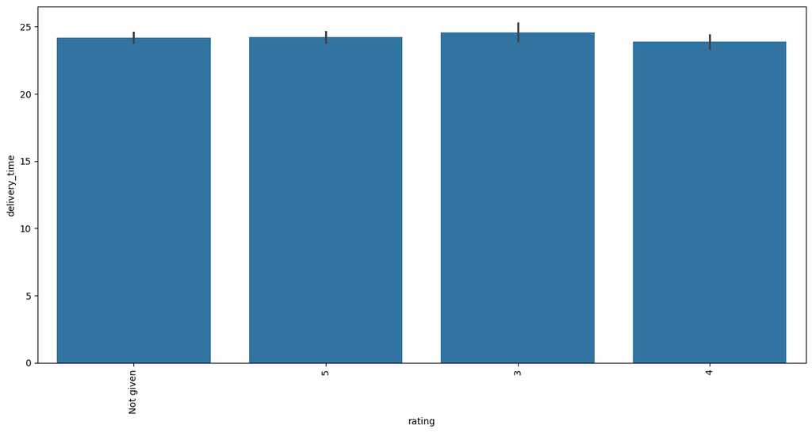

```python
plt.figure(figsize=(15,7))
sns.barplot(data=df_without_customerId, x='rating', y='delivery_time')
plt.xticks(rotation=90)
plt.show()
```

**Observations**

1. There is no relation between rating and delivery time.
2. Ideally it is expected that if the delivery time is high than the rating should go low.

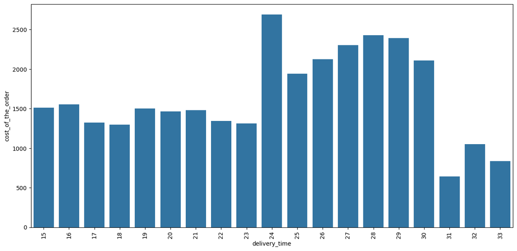

```python
plt.figure(figsize=(15,7))
sns.barplot(data=df_without_customerId.groupby('delivery_time')['cost_of_the_order'].sum())
plt.xticks(rotation=90)
plt.show()
```

#### Observation on Delivery Time and cost of the order

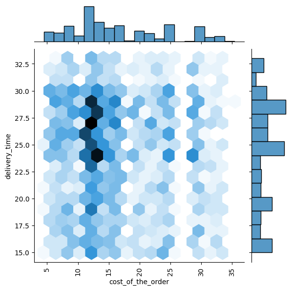

```python
plt.figure(figsize=(15,7))
sns.jointplot(data=df_without_customerId, y='delivery_time', x='cost_of_the_order', kind='hex')
plt.xticks(rotation=90)
plt.show()
```

**Observation**

1. There are many orders which are concentrated between 10 to 15 dollars where the delivery time is 22.5 - 30 minutes.

### **Question 13:** The company wants to provide a promotional offer in the advertisement of the restaurants. The condition to get the offer is that the restaurants must have a rating count of more than 50 and the average rating should be greater than 4. Find the restaurants fulfilling the criteria to get the promotional offer. [3 marks]

```python
filtered_df = df[df['rating'] != 'Not given']
filtered_df['rating'] = filtered_df['rating'].astype(float)

rating_counts = filtered_df.groupby('restaurant_name')['rating'].count()
qualified_restaurants_count = rating_counts[rating_counts > 50].index

mean_rating = filtered_df.groupby('restaurant_name')['rating'].mean()
qualified_restaurants_mean = mean_rating[mean_rating > 4].index

final_filtered_df = filtered_df[(filtered_df['restaurant_name'].isin(qualified_restaurants_count)) & (filtered_df['restaurant_name'].isin(qualified_restaurants_mean))]

final_filtered_df
```

|  | order_id | customer_id | restaurant_name | cuisine_type | cost_of_the_order | day_of_the_week | rating | food_preparation_time | delivery_time |
| --- | --- | --- | --- | --- | --- | --- | --- | --- | --- |
| 3 | 1477334 | 106968 | Blue Ribbon Fried Chicken | American | 29.20 | Weekend | 3.0 | 25 | 15 |
| 12 | 1476966 | 129969 | Blue Ribbon Fried Chicken | American | 24.30 | Weekend | 5.0 | 23 | 17 |
| 15 | 1477414 | 66222 | Shake Shack | American | 16.20 | Weekend | 5.0 | 33 | 25 |
| 19 | 1477354 | 67487 | Blue Ribbon Sushi | Japanese | 16.20 | Weekend | 4.0 | 35 | 26 |
| 22 | 1478287 | 150599 | Shake Shack | American | 29.10 | Weekday | 5.0 | 21 | 30 |
| ... | ... | ... | ... | ... | ... | ... | ... | ... | ... |
| 1880 | 1477466 | 222734 | Shake Shack | American | 13.97 | Weekend | 5.0 | 35 | 27 |
| 1884 | 1477437 | 304993 | Shake Shack | American | 31.43 | Weekend | 3.0 | 31 | 24 |
| 1885 | 1477550 | 97324 | Shake Shack | American | 29.05 | Weekday | 4.0 | 27 | 29 |
| 1886 | 1478277 | 48282 | The Meatball Shop | American | 14.50 | Weekend | 5.0 | 34 | 25 |
| 1888 | 1477353 | 106324 | The Meatball Shop | Italian | 16.20 | Weekend | 5.0 | 21 | 26 |

354 rows × 9 columns

```python
final_filtered_df['restaurant_name'].value_counts()
```

| restaurant_name | count |
| --- | --- |
| Shake Shack | 133 |
| The Meatball Shop | 84 |
| Blue Ribbon Sushi | 73 |
| Blue Ribbon Fried Chicken | 64 |

**dtype:** int64

```python
final_filtered_df.describe()
```

|  | order_id | customer_id | cost_of_the_order | rating | food_preparation_time | delivery_time |
| --- | --- | --- | --- | --- | --- | --- |
| count | 3.540000e+02 | 354.000000 | 354.000000 | 354.000000 | 354.000000 | 354.000000 |
| mean | 1.477520e+06 | 178725.090395 | 17.011582 | 4.330508 | 27.604520 | 24.347458 |
| std | 5.363928e+02 | 116913.125537 | 7.495781 | 0.749562 | 4.850348 | 4.893848 |
| min | 1.476548e+06 | 14869.000000 | 4.750000 | 3.000000 | 20.000000 | 15.000000 |
| 25% | 1.477079e+06 | 79612.000000 | 12.130000 | 4.000000 | 23.000000 | 21.000000 |
| 50% | 1.477543e+06 | 132143.000000 | 15.230000 | 4.500000 | 28.000000 | 25.000000 |
| 75% | 1.477974e+06 | 294250.000000 | 24.200000 | 5.000000 | 32.000000 | 28.000000 |
| max | 1.478444e+06 | 400390.000000 | 33.370000 | 5.000000 | 35.000000 | 33.000000 |

#### Observations:

There are total 4 restaurants which have count of ratings given more than 50 and the mean value of the rating is greater than 4.

### **Question 14:** The company charges the restaurant 25% on the orders having cost greater than 20 dollars and 15% on the orders having cost greater than 5 dollars. Find the net revenue generated by the company across all orders. [3 marks]

```python
# Write the code here
df_with_revenue25percent = df[df['cost_of_the_order'] > 20]
revenue25percent_order_sum = df_with_revenue25percent['cost_of_the_order'].sum()
total_25percentrevenue = 0.25 * revenue25percent_order_sum

df_with_revenue15percent = df[(df['cost_of_the_order'] > 5) & (df['cost_of_the_order'] < 20)]
revenue15percent_order_sum = df_with_revenue15percent['cost_of_the_order'].sum()
total_15percentrevenue = 0.15 * revenue15percent_order_sum

total_revenue = total_25percentrevenue + total_15percentrevenue
print("Total revenue of the company", total_revenue)
```

```
Total revenue of the company 6166.303
```

### **Question 15:** The company wants to analyze the total time required to deliver the food. What percentage of orders take more than 60 minutes to get delivered from the time the order is placed? (The food has to be prepared and then delivered.) [2 marks]

```python
# Write the code here
df['total_time_to_delivery'] = df['food_preparation_time'] + df['delivery_time']
rows_with_totaltimegreatethan60 = df[df['total_time_to_delivery'] > 60].shape[0]
total_rows = df.shape[0]
print("Percentage where delivery time is greater than 60 minuts", '{:.2f}%'.format((rows_with_totaltimegreatethan60/total_rows)*100))
```

```
Percentage where delivery time is greater than 60 minuts 10.54%
```

#### Observations:

Percentage where delivery time is greater than 60 minuts 10.54%

### **Question 16:** The company wants to analyze the delivery time of the orders on weekdays and weekends. How does the mean delivery time vary during weekdays and weekends? [2 marks]

```python
# Write the code here
df.groupby('day_of_the_week')['delivery_time'].mean()
```

| day_of_the_week | delivery_time |
| --- | --- |
| Weekday | 28.340037 |
| Weekend | 22.470022 |

**dtype:** float64

#### Observations:

Mean delivery time during weekday = 28.34 minutes

### Conclusion and Recommendations

### **Question 17:** What are your conclusions from the analysis? What recommendations would you like to share to help improve the business? (You can use cuisine type and feedback ratings to drive your business recommendations.) [6 marks]

### Conclusions:

- Most of the orders are placed during the Weekend
- Approximately 25% of the orders are from the top 3 restaurants.
- Delivery Time During the weekday is high.
- 784 Customers have ordered only once.
- Most favoured Cuisine is American(584 orders) and Japanese(470 Orders).

## Recommendations and Suggestions:

### Delivery

- Business needs to analyze the demand on the weekends and reduce the delivery time. This will help them to provide better customer experience and improve the ratings.
- The mean delivery Time for the restaurant with Highest orders Shake Shack is greater than the overall mean delivery time.

The data provided is not sufficient to analyze the patterns of the delivery partners availability. Business should collect more data to locate pattern in demand and supply of food orders and delivery partners

#### Customers

- There are 784 customers who have ordered only once. Efforts should be made to analyze that out of 1200 customers why 784 customers have not returned back and ordered.
- Discount offers could be provided to boost customer ordering on the platform.
- Feedback offers could be provided to gain insights and data various services offered like total delivery time, restaurant food quality, Cost of the order etc.

#### Restaurants

- Since around 25% of the orders are coming from the top 3 restaurant out of 178 restaurants, more analysis is required to understand what are the reasons that the orders are not coming from those restaurants.
- Some of the reasons orders are coming low could be poor food quality, poor customer service, less food quantity wrt cost of the order.